# Latihan Analisis Biplot Universitas

DIANI RARAS PUSPITA

2025-11-19

## Input Data

```r
data <- data.frame(
  University = c("Harvard", "Princeton", "Yale", "Stanford", "MIT", "Duke"),
  SAT       = c(14.00, 13.75, 13.75, 13.60, 13.80, 13.15),
  Top10     = c(91, 91, 95, 90, 94, 90),
  Accept    = c(14, 14, 19, 20, 30, 30),
  SFRatio   = c(11, 8, 11, 12, 10, 12),
  Expenses  = c(39.525, 30.220, 43.514, 36.450, 34.870, 31.585),
  Grad      = c(97, 95, 96, 93, 91, 95)
)

data$Nama <- data$University
```

## Buat Matrix X

```r
X <- as.matrix(data[, c("SAT","Top10","Accept","SFRatio","Expenses","Grad")])
X
```

```
##        SAT Top10 Accept SFRatio Expenses Grad
## [1,] 14.00    91     14      11   39.525   97
## [2,] 13.75    91     14       8   30.220   95
## [3,] 13.75    95     19      11   43.514   96
## [4,] 13.60    90     20      12   36.450   93
## [5,] 13.80    94     30      10   34.870   91
## [6,] 13.15    90     30      12   31.585   95
```

## Buat Matrix XtX

```r
XtX <- t(X) %*% X
XtX
```

```
##               SAT    Top10    Accept  SFRatio  Expenses     Grad
## SAT      1122.448  7536.20  1730.250  874.250  2959.461  7754.10
## Top10    7536.200 50623.00 11673.000 5874.000 19881.555 52066.00
## Accept   1730.250 11673.00  2953.000 1375.000  4525.846 11952.00
## SFRatio   874.250  5874.00  1375.000  694.000  2320.309  6049.00
## Expenses 2959.461 19881.56  4525.846 2320.309  7911.074 20445.76
## Grad     7754.100 52066.00 11952.000 6049.000 20445.764 53605.00
```

## Eigenvalues & Eigenvectors

```r
eig <- eigen(XtX)
lambda <- eig$values
A <- eig$vectors
```

## L dan L inverse

```r
L <- diag(sqrt(lambda))
L.inv <- solve(L)
```

## Matriks U

```r
U <- X %*% L.inv %*% t(A)
U
```

```
##          [,1]      [,2]     [,3]      [,4]     [,5]     [,6]
## [1,] 214.7252 -59.72674 15.88232 -70.38421 22.75557 22.61921
## [2,] 212.2228 -55.90034 14.19815 -63.66060 20.75835 19.64408
## [3,] 211.5591 -60.27159 15.96493 -72.64245 22.88964 23.79332
## [4,] 206.1976 -57.06872 14.78111 -66.48324 21.01686 21.74164
## [5,] 202.0083 -55.37686 13.78915 -64.91280 19.51789 21.31992
## [6,] 211.9209 -56.74455 14.23333 -64.36845 19.55522 21.04244
```

## Matriks H transpose

```r
Ht <- L %*% t(A)
Ht
```

```
##             [,1]          [,2]         [,3]         [,4]         [,5]
## [1,] -33.4941619 -224.97272515 -51.84329698 -26.14156721 -88.40514383
## [2,]   0.3338025   -0.72987758 -16.18543134  -0.99346267   4.48980783
## [3,]   0.3349936    0.31269856  -1.73735107  -1.50763594  -8.67468393
## [4,]  -0.3151191   -3.07948181   0.49175500   2.52738569   0.35637206
## [5,]  -0.3306371   -0.39001609   0.20835548  -0.98209118   0.26098651
## [6,]   0.3954138   -0.08435753   0.02733179  -0.07967464   0.02755185
##               [,6]
## [1,] -231.47131345
## [2,]    2.68360166
## [3,]    3.52008923
## [4,]    2.50694097
## [5,]    0.39148011
## [6,]    0.01712615
```

## Ambil komponen 2D

```r
G_star <- U[,1:2]
Ht_star <- Ht[1:2,]
```

## Goodness of fit

```r
rho2 <- sum(lambda[1:2]) / sum(lambda)
rho2
```

```
## [1] 0.9989956
```

## Biplot

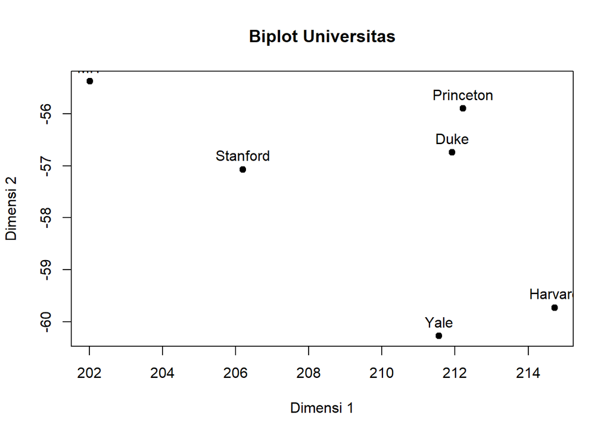

```r
plot(G_star, pch=19,
     xlab="Dimensi 1",
     ylab="Dimensi 2",
     main="Biplot Universitas")

text(G_star, labels=data$Nama, pos=3)

arrows(0, 0, Ht_star[1,], Ht_star[2,], col="red", length=0.12)

text(Ht_star[1,], Ht_star[2,],
     labels=colnames(X),
     col="red", pos=3)
```

## Kesimpulan

Biplot yang dihasilkan menggambarkan posisi enam universitas berdasarkan kombinasi beberapa variabel akademik dan karakteristik institusi. Titik-titik pada biplot mewakili universitas, sedangkan dua dimensi utama mewakili komponen yang merangkum variasi terbesar dari seluruh variabel.

Secara umum, universitas dengan karakteristik yang mirip akan berada pada posisi yang berdekatan, sedangkan universitas yang berbeda karakteristiknya akan berada lebih jauh satu sama lain. Pada grafik terlihat bahwa Princeton dan Duke terletak cukup berdekatan, menunjukkan bahwa kedua universitas ini memiliki profil yang serupa dari sisi nilai SAT, proporsi mahasiswa top school, tingkat penerimaan, rasio fakultas-mahasiswa, biaya pendidikan, maupun tingkat kelulusan.

Stanford muncul di posisi tengah dan agak terpisah dari kelompok universitas lainnya. Hal ini mencerminkan bahwa Stanford memiliki kombinasi karakteristik yang tidak terlalu ekstrem terhadap salah satu variabel dan cenderung berada di tingkat menengah, sehingga tidak terlalu mirip maupun terlalu berbeda dengan universitas lain.

Sementara itu, Yale dan Harvard menempati sisi kanan bawah biplot. Meskipun keduanya tidak berdekatan satu sama lain, posisi ini menunjukkan bahwa keduanya memiliki ciri khusus yang membuat mereka berbeda dibanding universitas lain dalam dataset, terutama terkait pada variabel-variabel yang memberikan kontribusi besar terhadap dimensi kedua. Harvard berada di sisi paling kanan, menandakan adanya karakteristik yang cukup ekstrem pada salah satu dimensi utama.

Di sisi lain, terdapat satu titik yang berada di sisi kiri atas biplot (kemungkinan MIT, sesuai urutan data). Universitas ini memiliki profil yang paling berbeda dibanding universitas lainnya, terutama pada komponen dimensi kedua. Jarak yang jauh dari Harvard dan Yale mengindikasikan bahwa pola karakteristiknya bertolak belakang dengan keduanya.

Secara keseluruhan, biplot ini membantu menunjukkan kelompok universitas yang memiliki karakteristik serupa, serta universitas yang memiliki profil sangat khas atau berbeda, berdasarkan berbagai indikator kualitas akademik dan institusional.